# Mouse Ileum Analysis

Zhaorong Li

Jan/11/2022

# 1 MERFISH Image visualization

This dataset [1] is downloaded from https://zenodo.org/record/5512749#.Yd3H0dHMKUl. The Baysor Cell segmentation and the author generated cell type assignment are used in the analysis.

## 1.1 Plot Cell by centroid Coordinates

```r
Spacial.information=read.csv('segmentation.csv.gz',header = T)

Spacial.information=Spacial.information[Spacial.information$is_noise!='true',]
Spacial.information$cell=as.character(Spacial.information$cell)
Cell_spacial_information=read.csv('segmentation_cell_stats.csv.gz',header = T,row.names = 1)

Celltype=read.csv('cell_assignment.csv.gz',header = T,row.names = 1)
colnames(Celltype)=c('Celltype')

Cell_spacial_information=merge(Cell_spacial_information,Celltype,by = 0)
colnames(Cell_spacial_information)=paste0('cell_',colnames(Cell_spacial_information))

colnames(Cell_spacial_information)[1]='cell'

Cell_spacial_information=Cell_spacial_information[Cell_spacial_information$cell_Celltype!='Removed',]
getPalette = colorRampPalette(brewer.pal(9, "Dark2"))
```

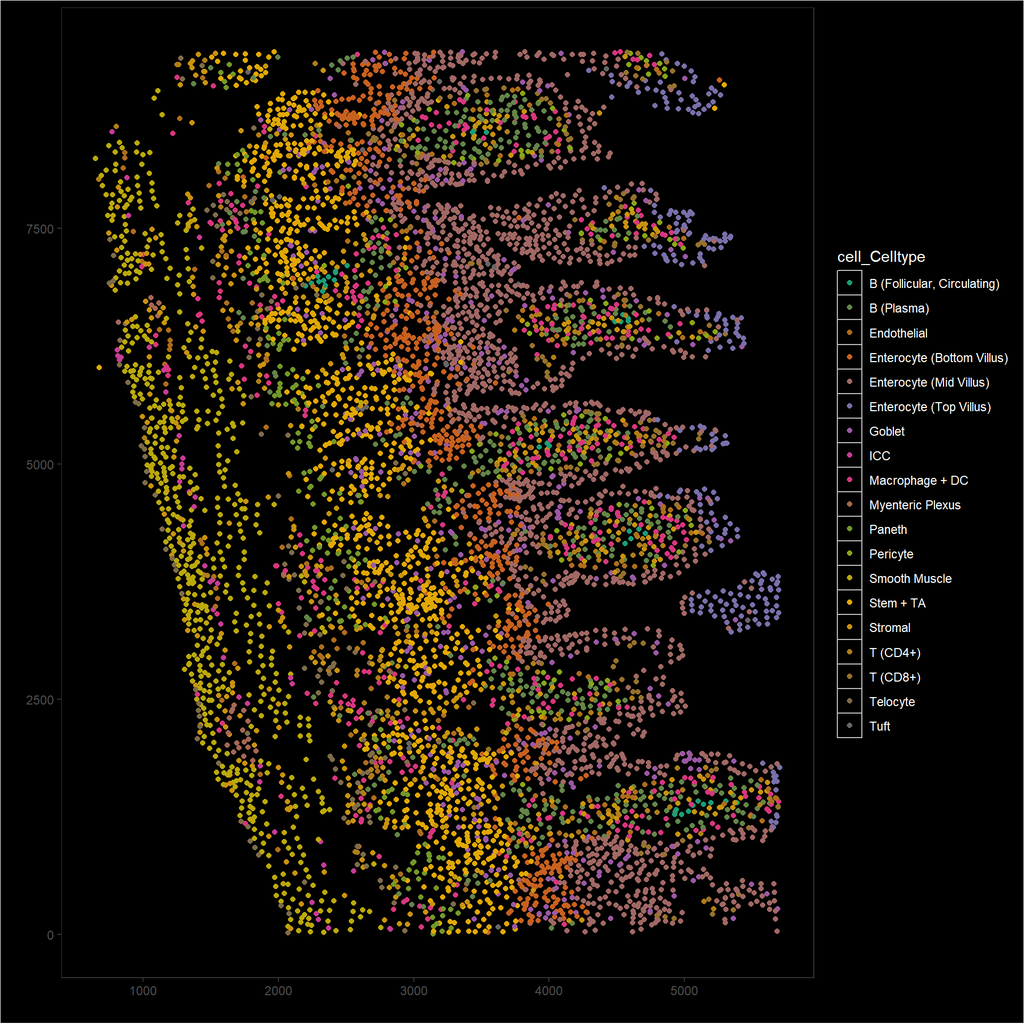

```r
color=getPalette(length(unique(Cell_spacial_information$cell_Celltype)))

ggplot(Cell_spacial_information,aes(x=cell_x,y=cell_y,colour=cell_Celltype))+geom_point()+
  xlim(min(Cell_spacial_information$cell_x),max(Cell_spacial_information$cell_x))+
  ylim(min(Cell_spacial_information$cell_y),max(Cell_spacial_information$cell_y)) + scale_color_manual(values = color)+ theme_bw() +
  theme(
    # get rid of panel grids
    panel.grid.major = element_blank(),
    panel.grid.minor = element_blank(),
    # Change plot and panel background
    plot.background=element_rect(fill = "black"),
    panel.background = element_rect(fill = 'black'),
    # Change legend
    #legend.position = c(0.6, 0.07),
    #legend.direction = "horizontal",
    legend.background = element_rect(fill = "black", color = NA),
    legend.key = element_rect(color = "gray", fill = "black"),
    legend.title = element_text(color = "white"),
    legend.text = element_text(color = "white")
  )
```

## 1.2 Plot Cell by real probes.

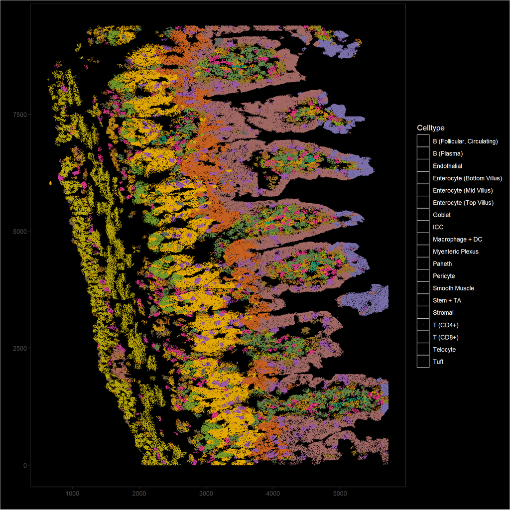

```r
Spacial.information=Spacial.information[Spacial.information$cell%in%rownames(Cell_spacial_information),]

Spacial.information=merge(Spacial.information,Cell_spacial_information,by = 'cell')

colnames(Spacial.information)[grepl('Celltype',colnames(Spacial.information))]='Celltype'


ggplot(Spacial.information,aes(x=x,y=y,colour=Celltype))+geom_point(shape='.')+
  xlim(min(Spacial.information$x),max(Spacial.information$x))+
  ylim(min(Spacial.information$y),max(Spacial.information$y)) + scale_color_manual(values = color)+ theme_bw() +
  theme(
    # get rid of panel grids
    panel.grid.major = element_blank(),
    panel.grid.minor = element_blank(),
    # Change plot and panel background
    plot.background=element_rect(fill = "black"),
    panel.background = element_rect(fill = 'black'),
    # Change legend
    #legend.position = c(0.6, 0.07),
    #legend.direction = "horizontal",
    legend.background = element_rect(fill = "black", color = NA),
    legend.key = element_rect(color = "gray", fill = "black"),
    legend.title = element_text(color = "white"),
    legend.text = element_text(color = "white")
  )
```

# 2 Analysis

By looking at the visualization results from Part 1, we can see that the cellular composition of different parts of the tissue are different.

Can we use the unsupervised clustering algorithm to find different parts of the tissue?

Time to find out.

## 2.1 Area Calculator Function

This function will break the Image into multiple small fragments. and calculate the cell composition in each small fragments.

```
Logic:
  The whole image is broken into small fragments.

  for each small fragment:

    for each cell has overlap with the small fragment:

      if the cell has more than x% (x determined by the user) of cell's probes'areas in the small fragment, the cell is determined to be in the small fragment.
    Cell composition of the small fragment is determined by the cells assigned to it.
```

The percentage threshold and the size of small fragment can be determined by the user.

One tip: if the number of fragments is increased, please decrease the proportion_threshold. Otherwise many area will be deemed as no cells.

```r
source('functions.R')
```

```r
Area.50.50=Area_Calculator(min(Spacial.information$x),
                                 max(Spacial.information$x),
                                 min(Spacial.information$y),
                                 max(Spacial.information$y),
                                 50,Spacial.information,proportion_threshold = 0.5)





reactable(Area.50.50)
```

|  | Telocyte | Smooth Muscle | Stromal | Goblet | Enterocyte (Mid Villus) | B (Plasma) | Stem + TA | Endothelial | T (CD8+) | T (CD4+) | Macrophage + DC | ICC | Enterocyte (Bottom Villus) | Paneth | Myenteric Plexus | Pericyte | B (Follicular, Circulating) | Enterocyte (Top Villus) | Tuft |
| --- | --- | --- | --- | --- | --- | --- | --- | --- | --- | --- | --- | --- | --- | --- | --- | --- | --- | --- | --- |
| 632,733.76,6010.24,6198.06 | 0 | 0 | 0 | 0 | 0 | 0 | 1 | 0 | 0 | 0 | 0 | 0 | 0 | 0 | 0 | 0 | 0 | 0 | 0 |
| 632,733.76,7700.62,7888.44 | 0 | 1 | 0 | 0 | 0 | 0 | 0 | 0 | 0 | 0 | 0 | 0 | 0 | 0 | 0 | 0 | 0 | 0 | 0 |
| 632,733.76,7888.44,8076.25999999999 | 0 | 2 | 0 | 0 | 0 | 0 | 0 | 0 | 0 | 1 | 0 | 0 | 0 | 0 | 0 | 0 | 0 | 0 | 0 |
| 632,733.76,8076.25999999999,8264.07999999999 | 0 | 2 | 0 | 0 | 0 | 0 | 0 | 0 | 0 | 0 | 0 | 0 | 0 | 0 | 0 | 0 | 0 | 0 | 0 |
| 733.76,835.52,6010.24,6198.06 | 1 | 0 | 0 | 0 | 0 | 0 | 0 | 0 | 0 | 0 | 0 | 2 | 0 | 0 | 0 | 0 | 0 | 0 | 0 |
| 733.76,835.52,6198.06,6385.88 | 0 | 0 | 0 | 0 | 0 | 0 | 0 | 0 | 0 | 0 | 0 | 1 | 0 | 0 | 0 | 0 | 0 | 0 | 0 |
| 733.76,835.52,6385.88,6573.7 | 0 | 0 | 0 | 0 | 1 | 0 | 0 | 0 | 0 | 0 | 0 | 0 | 0 | 0 | 0 | 0 | 0 | 0 | 0 |
| 733.76,835.52,6761.52,6949.34 | 0 | 1 | 1 | 0 | 0 | 0 | 0 | 0 | 0 | 0 | 0 | 0 | 0 | 0 | 0 | 0 | 0 | 0 | 0 |
| 733.76,835.52,6949.34,7137.16 | 0 | 2 | 0 | 0 | 0 | 0 | 0 | 0 | 0 | 0 | 0 | 0 | 0 | 0 | 0 | 0 | 0 | 0 | 0 |
| 733.76,835.52,7137.16,7324.98 | 1 | 0 | 0 | 0 | 0 | 0 | 0 | 0 | 0 | 0 | 0 | 0 | 0 | 0 | 0 | 0 | 0 | 0 | 0 |

[output cut: 1771 more lines]

## 2.2 Normalization and Scaling

The cell composition of each fragment is scaled by the total number of cells in the fragment. The scaled number is multiplied by 1,000,000 and then log transformed.

Basically it is log transformed CPM normalized. This step is included in the Area_Cluster() function.

```r
Area.50.50.normalized=Area.50.50/rowSums(Area.50.50)
Area.50.50.normalized=Area.50.50.normalized*(1e6)
Area.50.50.normalized=log(Area.50.50.normalized+1)

reactable(Area.50.50)
```

|  | Telocyte | Smooth Muscle | Stromal | Goblet | Enterocyte (Mid Villus) | B (Plasma) | Stem + TA | Endothelial | T (CD8+) | T (CD4+) | Macrophage + DC | ICC | Enterocyte (Bottom Villus) | Paneth | Myenteric Plexus | Pericyte | B (Follicular, Circulating) | Enterocyte (Top Villus) | Tuft |
| --- | --- | --- | --- | --- | --- | --- | --- | --- | --- | --- | --- | --- | --- | --- | --- | --- | --- | --- | --- |
| 632,733.76,6010.24,6198.06 | 0 | 0 | 0 | 0 | 0 | 0 | 1 | 0 | 0 | 0 | 0 | 0 | 0 | 0 | 0 | 0 | 0 | 0 | 0 |
| 632,733.76,7700.62,7888.44 | 0 | 1 | 0 | 0 | 0 | 0 | 0 | 0 | 0 | 0 | 0 | 0 | 0 | 0 | 0 | 0 | 0 | 0 | 0 |
| 632,733.76,7888.44,8076.25999999999 | 0 | 2 | 0 | 0 | 0 | 0 | 0 | 0 | 0 | 1 | 0 | 0 | 0 | 0 | 0 | 0 | 0 | 0 | 0 |
| 632,733.76,8076.25999999999,8264.07999999999 | 0 | 2 | 0 | 0 | 0 | 0 | 0 | 0 | 0 | 0 | 0 | 0 | 0 | 0 | 0 | 0 | 0 | 0 | 0 |
| 733.76,835.52,6010.24,6198.06 | 1 | 0 | 0 | 0 | 0 | 0 | 0 | 0 | 0 | 0 | 0 | 2 | 0 | 0 | 0 | 0 | 0 | 0 | 0 |
| 733.76,835.52,6198.06,6385.88 | 0 | 0 | 0 | 0 | 0 | 0 | 0 | 0 | 0 | 0 | 0 | 1 | 0 | 0 | 0 | 0 | 0 | 0 | 0 |
| 733.76,835.52,6385.88,6573.7 | 0 | 0 | 0 | 0 | 1 | 0 | 0 | 0 | 0 | 0 | 0 | 0 | 0 | 0 | 0 | 0 | 0 | 0 | 0 |
| 733.76,835.52,6761.52,6949.34 | 0 | 1 | 1 | 0 | 0 | 0 | 0 | 0 | 0 | 0 | 0 | 0 | 0 | 0 | 0 | 0 | 0 | 0 | 0 |
| 733.76,835.52,6949.34,7137.16 | 0 | 2 | 0 | 0 | 0 | 0 | 0 | 0 | 0 | 0 | 0 | 0 | 0 | 0 | 0 | 0 | 0 | 0 | 0 |
| 733.76,835.52,7137.16,7324.98 | 1 | 0 | 0 | 0 | 0 | 0 | 0 | 0 | 0 | 0 | 0 | 0 | 0 | 0 | 0 | 0 | 0 | 0 | 0 |

[output cut: 1771 more lines]

## 2.3 Clustering

In this case I used the Louvain Community Clustering Algorithm from igraph package to cluster the area.

```r
clusterlouvain <- Area_Cluster(Area.50.50,ScaleFactor = 1e6,0.5)
```

## 2.4 Visualization of Clustering Results

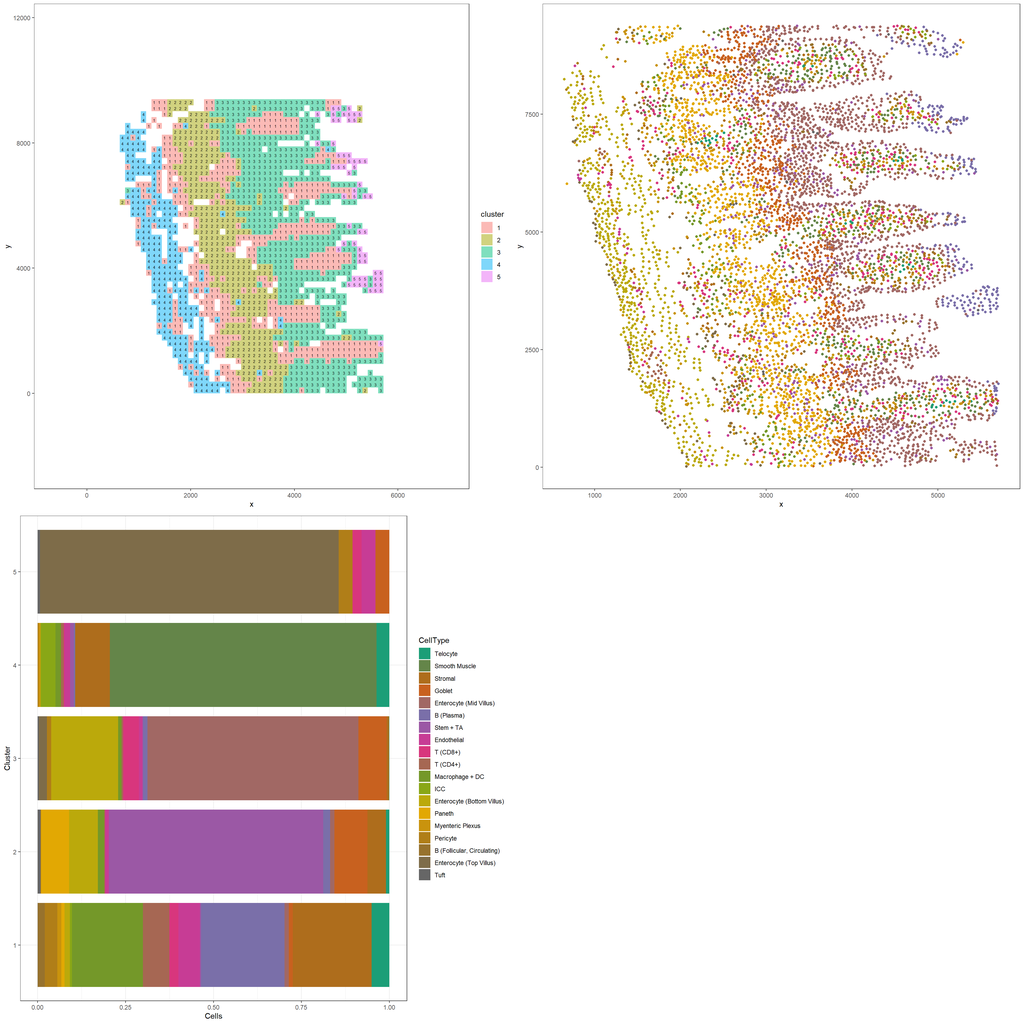

```r
Area.Cluster.assignment=clusterlouvain$Area.Cluster.assignment

Clustering.Distribution=clusterlouvain$Clustering.Distribution

melt=Area.Cluster.assignment
melt$cluster=as.factor(melt$cluster)
melt=melt(melt,id.vars='cluster')
colnames(melt)=c('Cluster','CellType','Cells')
Cluster_cell_composition=ggplot(melt,aes(x=Cells,y=Cluster,fill=CellType))+geom_bar(stat = 'identity',position = 'fill')+ scale_fill_manual(values = color)+ theme_bw()

centroid.graph=ggplot(Cell_spacial_information,aes(x=cell_x,y=cell_y,colour=cell_Celltype))+geom_point()+
  xlim(min(Cell_spacial_information$cell_x),max(Cell_spacial_information$cell_x))+
  ylim(min(Cell_spacial_information$cell_y),max(Cell_spacial_information$cell_y)) + scale_color_manual(values = color)+ theme_bw() +xlab('x') +ylab('y') +
  theme(legend.position = "none",
    # get rid of panel grids
    panel.grid.major = element_blank(),
    panel.grid.minor = element_blank(),
    # Change plot and panel background
    # Change legend
    #legend.position = c(0.6, 0.07),
    #legend.direction = "horizontal",
)
Clustering.Distribution.plot=clusterlouvain$Clustering.Distribution.plot

grid.arrange(Clustering.Distribution.plot, centroid.graph,Cluster_cell_composition, ncol=2)
```

## 2.5 Explore the Transcriptome Based on the Area Clustering Results

The Clustering algorithm separate the image into 5 clusters.

Cluster 4 is the muscle lining of the Ileum.

Cluster 3 and 5 are the outside lining of the Villi. Cluster 5 is the tip of the villus which is rich in Top Villus Enterocytes. while Cluster 3 is rich in Mid Villus and Bottom Villus Enterocytes.

```r
Cell_spacial_information$Area_Cluster=''

for (i in 1:nrow(Cell_spacial_information)) {
  start=1
  stop=0
  while(start<=nrow(Clustering.Distribution)&stop==0) {
    if (Cell_spacial_information$cell_x[i]>Clustering.Distribution$xmin[start]&
        Cell_spacial_information$cell_x[i]<Clustering.Distribution$xmax[start]&
        Cell_spacial_information$cell_y[i]>Clustering.Distribution$ymin[start]&
        Cell_spacial_information$cell_y[i]<Clustering.Distribution$ymax[start]) {
      Cell_spacial_information$Area_Cluster[i]=Clustering.Distribution$cluster[start]
      stop=1
    }
    else {
      start=start+1
    }
  }
  rm(i)
}
write.table(Cell_spacial_information,'Cell_spacial_information.tsv',quote = F,sep = '\t',row.names = F)

reactable(Cell_spacial_information)
```

| cell | cell_x | cell_y | cell_n_transcripts | cell_density | cell_elongation | cell_area | cell_avg_confidence | cell_Celltype | Area_Cluster |
| --- | --- | --- | --- | --- | --- | --- | --- | --- | --- |
| 1 | 2070.40476190476 | 19.0238095238095 | 42 | 0.01717 | 4.075 | 2446 | 0.8952 | Telocyte | 4 |
| 10 | 2334.70526315789 | 24.6105263157895 | 95 | 0.01564 | 1.756 | 6074 | 0.9135 | Smooth Muscle | 4 |
| 100 | 2955.78409090909 | 107.727272727273 | 88 | 0.01363 | 2.111 | 6458 | 0.926 | Stromal | 1 |
| 1000 | 1499.78461538462 | 3632.44615384615 | 65 | 0.01603 | 1.735 | 4054 | 0.9885 | Smooth Muscle | 4 |
| 1001 | 3122.12941176471 | 1913.57647058824 | 170 | 0.0234 | 2.248 | 7264 | 1 | Goblet | 2 |
| 1002 | 3049.81318681319 | 2061.6043956044 | 91 | 0.01973 | 2.354 | 4613 | 0.9995 | Stem + TA | 2 |
| 1003 | 4298.625 | 759.375 | 16 | 0.01114 | 4.92 | 1436 | 0.9945 | Enterocyte (Mid Villus) | 3 |
| 1004 | 4709.83163265306 | 379.280612244898 | 196 | 0.02201 | 1.465 | 8906 | 0.9895 | Enterocyte (Mid Villus) | 3 |
| 1005 | 4887.18487394958 | 324.558823529412 | 238 | 0.01913 | 1.853 | 12440 | 0.993 | Enterocyte (Mid Villus) | 3 |
| 1006 | 4001.12849162011 | 1135.62011173184 | 179 | 0.01942 | 2.711 | 9216 | 0.9375 | B (Plasma) | 1 |

[output cut: 7406 more lines]

```r
metadata=Cell_spacial_information
# Remove the cells that are not in the any Area cluster.
metadata=metadata[metadata$Area_Cluster!='',]

rownames(metadata)=metadata$cell
Counts=read.table('MERFISH/data_release_baysor_merfish_gut/data_analysis/baysor_membrane_prior/segmentation/segmentation_counts.tsv',header = F,row.names = 1,check.names = F)
colnames(Counts)=seq(1,ncol(Counts))
Counts=Counts[,rownames(metadata)]
Seurat_Object=CreateSeuratObject(Counts,meta.data = metadata)



Enterocyte=subset(Seurat_Object,subset=cell_Celltype%in%c('Enterocyte (Mid Villus)','Enterocyte (Bottom Villus)',
                                                          'Enterocyte (Top Villus)'))
Enterocyte=NormalizeData(Enterocyte)
Idents(Enterocyte)='Area_Cluster'
reactable(data.frame(table(Enterocyte$Area_Cluster)))
```

| Var1 | Freq |
| --- | --- |
| 1 | 72 |
| 2 | 168 |
| 3 | 2168 |
| 4 | 2 |
| 5 | 162 |

```r
Enterocyte.Area.markers=FindAllMarkers(Enterocyte,test.use = 'MAST',only.pos = T)
```

[output not shown]

[output cut: 30 more lines]

[output not shown]

```r
reactable(Enterocyte.Area.markers)
```

|  | p_val | avg_log2FC | pct.1 | pct.2 | p_val_adj | cluster | gene |
| --- | --- | --- | --- | --- | --- | --- | --- |
| Slc51a | 7.40112059898977e-94 | 1.01141056169568 | 0.978 | 0.911 | 1.78367006435654e-91 | 3 | Slc51a |
| Maoa | 1.03613920696394e-52 | 1.26810236232618 | 0.83 | 0.609 | 2.49709548878309e-50 | 3 | Maoa |
| Slc5a1 | 3.65692700211442e-52 | 0.877195303563294 | 0.948 | 0.889 | 8.81319407509575e-50 | 3 | Slc5a1 |
| Nlrp6 | 4.76121229821034e-31 | 0.410302948503068 | 0.806 | 0.527 | 1.14745216386869e-28 | 3 | Nlrp6 |
| Lpar1 | 1.00927485663182e-09 | 0.603078851594217 | 0.565 | 0.413 | 2.4323524044827e-07 | 3 | Lpar1 |
| Sdc1 | 2.84863693349759e-09 | 0.397211253409873 | 0.857 | 0.795 | 6.8652150097292e-07 | 3 | Sdc1 |
| H2-Eb1 | 0.000342518278967504 | 0.393556904141773 | 0.592 | 0.522 | 0.0825469052311684 | 3 | H2-Eb1 |
| Acta2 | 0.000467662434485052 | 0.44199660848092 | 0.389 | 0.319 | 0.112706646710898 | 3 | Acta2 |
| Acsl1 | 0.00617601686859043 | 0.536713454008608 | 0.298 | 0.252 | 1 | 3 | Acsl1 |
| Taar7a | 0.00767282179768226 | 0.697958326702723 | 0.243 | 0.223 | 1 | 3 | Taar7a |

[output cut: 53 more lines]

Gene Introduction:

https://www.genecards.org/cgi-bin/carddisp.pl?gene=APOB

https://www.genecards.org/cgi-bin/carddisp.pl?gene=SLC51A&keywords=Slc51a

https://www.genecards.org/cgi-bin/carddisp.pl?gene=STMN1&keywords=Stmn1

# 3 Conclusion

Coming soon.

# 4 Reference

[1] Moffitt, Jeffrey, Xu, Rosalind, Kharchenko, Peter, Petukhov, Viktor, Cadinu, Paolo, Soldatov, Ruslan, & Khodosevich, Konstantin. (2021). MERFISH measurements in the mouse ileum [Data set]. https://doi.org/10.5061/dryad.jm63xsjb2